# nppCART – usage (with pruning)

This vignette demonstrates how to use the pruning functionality of **nppCART**, which can be invoked if the probability sample is equipped with bootstrap weights.

Outline of this vignette:

- Section 1: create data for a synthetic population,
- Section 2: generate a pair of non-probability sample and probability sampe from the synthetic population,
- Section 3: estimate the self-selection propensities – according to the unpruned and pruned trees, respectively – for the units in the non-probability sample using **nppCART**.

### Section 1. Generate the synthetic population data frame.

First, we load the required R packages.

```r
library(nppR);
```

The following code segment uses the function **nppR::get.synthetic.population( )** in order to generate data for a synthetic population and store the data in the data frame **DF.population**. This synthetic population is designed so that the unpruned tree will over-fit, which can then serve to showcases the utility of pruning in such scenarios.

For reproducibility, we supply a randomization seed.

```r
DF.population <- nppR::get.synthetic.population(
    population.size = 10000,
    seed            = 7654321
    );
```

Here are the first few rows of **DF.population**:

```r
knitr::kable(head(DF.population), align = "c", row.names = FALSE);
```

| unit.ID | y | x1 | x2 | x3 | true.propensity |
| --- | --- | --- | --- | --- | --- |
| 1 | 110.01565 | small.1 | moyen.1 | 0.9 | 0.0079423 |
| 2 | 30.10283 | large.1 | petit.1 | 1.1 | 0.0035972 |
| 3 | 110.03128 | medium.1 | grand.1 | 2.9 | 0.0083338 |
| 4 | 110.14383 | medium.2 | grand.2 | 1.1 | 0.0080238 |
| 5 | 30.07629 | medium.2 | petit.2 | 2.1 | 0.0038879 |
| 6 | 110.25706 | medium.2 | petit.2 | 2.9 | 0.0082992 |

We remark that *y* is intended to be the target variable, while *x<sub>1</sub>*, *x<sub>2</sub>*, and *x<sub>3</sub>* are the predictor variables. The **true.propensity** is, of course, unknown in practice. Here are the structure and summary statistics of **DF.population**:

```r
utils::str(DF.population);
```

```
#> 'data.frame':    10000 obs. of  6 variables:
#>  $ unit.ID        : int  1 2 3 4 5 6 7 8 9 10 ...
#>  $ y              : num  110 30.1 110 110.1 30.1 ...
#>  $ x1             : Ord.factor w/ 6 levels "small.1"<"small.2"<..: 1 5 3 4 4 4 1 6 6 2 ...
#>  $ x2             : Ord.factor w/ 6 levels "petit.1"<"petit.2"<..: 3 1 5 6 2 2 5 2 2 3 ...
#>  $ x3             : num  0.9 1.1 2.9 1.1 2.1 2.9 1.9 3.1 0.9 1.9 ...
#>  $ true.propensity: num  0.00794 0.0036 0.00833 0.00802 0.00389 ...
```

```r
base::summary(DF.population);
```

```
#>     unit.ID            y                 x1             x2
#>  Min.   :    1   Min.   : 30.00   small.1 :1648   petit.1:1662
#>  1st Qu.: 2501   1st Qu.: 30.41   small.2 :1677   petit.2:1668
#>  Median : 5000   Median : 35.07   medium.1:1729   moyen.1:1716
#>  Mean   : 5000   Mean   : 69.94   medium.2:1579   moyen.2:1630
#>  3rd Qu.: 7500   3rd Qu.:110.41   large.1 :1676   grand.1:1652
#>  Max.   :10000   Max.   :123.87   large.2 :1691   grand.2:1672
#>        x3        true.propensity
#>  Min.   :0.900   Min.   :0.003425
#>  1st Qu.:1.100   1st Qu.:0.003993
#>  Median :1.900   Median :0.004279
#>  Mean   :1.988   Mean   :0.005945
#>  3rd Qu.:2.900   3rd Qu.:0.007996
#>  Max.   :3.100   Max.   :0.008620
```

### Section 2. Generate data frames for the non-probability and probability samples.

We now generate a pair of non-probability and probablity samples using the function **nppR::get.npp.samples()**.

The non-probability sample is a Poisson sample from the synthetic population each of whose units is selected – independently from all other units – according to its own unit-specific (true) self-selection propensity.

The probablity sample is a simple random sample (SRS) from the synthetic population.

The function **nppR::get.npp.samples()** allows the specification of the selection probablity of the SRS through the input parameter **prob.selection**, and the number of sets of bootstrap weights through **n.replicates**.

We store data for the non-probability sample in the data frame **DF.non.probability**, and that of the probability sample in **DF.probability**.

```r
n.replicates   <- 200;
prob.selection <- 0.2;

list.samples  <- nppR::get.npp.samples(
    DF.population  = DF.population,
    prob.selection = prob.selection,
    n.replicates   = n.replicates,
    seed           = 7654321
    );
DF.non.probability <- list.samples[['DF.non.probability']];
DF.probability     <- list.samples[['DF.probability'    ]];
```

Here are the first few rows of **DF.non.probability**:

```r
knitr::kable(head(DF.non.probability), align = "c", row.names = FALSE);
```

| unit.ID | y | x1 | x2 | x3 |
| --- | --- | --- | --- | --- |
| 161 | 110.0036 | small.1 | moyen.2 | 2.9 |
| 233 | 30.8090 | large.1 | grand.2 | 0.9 |
| 261 | 110.3961 | large.1 | petit.1 | 1.9 |
| 533 | 110.9432 | medium.1 | moyen.1 | 1.9 |
| 917 | 110.2015 | large.2 | moyen.2 | 3.1 |
| 943 | 113.5420 | medium.1 | grand.1 | 3.1 |

And, the first few rows of **DF.probability**:

```r
knitr::kable(head(DF.probability), align = "c", row.names = FALSE);
```

| unit.ID | x1 | x2 | x3 | sampling.fraction | design.weight | repweight1 | repweight2 | repweight3 | repweight4 | repweight5 | repweight6 | repweight7 | repweight8 | repweight9 | repweight10 | repweight11 | repweight12 | repweight13 | repweight14 | repweight15 | repweight16 | repweight17 | repweight18 | repweight19 | repweight20 | repweight21 | repweight22 | repweight23 | repweight24 | … |
| --- | --- | --- | --- | --- | --- | --- | --- | --- | --- | --- | --- | --- | --- | --- | --- | --- | --- | --- | --- | --- | --- | --- | --- | --- | --- | --- | --- | --- | --- | --- |
| 1 | small.1 | moyen.1 | 0.9 | 0.2 | 5 | 0 | 2 | 1 | 0 | 1 | 2 | 0 | 0 | 2 | 1 | 2 | 0 | 2 | 0 | 1 | 0 | 0 | 3 | 0 | 1 | 1 | 2 | 1 | 2 | … |
| 6 | medium.2 | petit.2 | 2.9 | 0.2 | 5 | 1 | 1 | 3 | 1 | 0 | 0 | 1 | 0 | 1 | 1 | 1 | 1 | 2 | 1 | 1 | 0 | 1 | 1 | 1 | 0 | 0 | 0 | 1 | 0 | … |
| 21 | medium.1 | petit.2 | 3.1 | 0.2 | 5 | 1 | 2 | 0 | 1 | 0 | 0 | 1 | 1 | 2 | 1 | 0 | 0 | 1 | 1 | 1 | 0 | 1 | 2 | 2 | 2 | 1 | 1 | 2 | 1 | … |
| 24 | large.2 | petit.2 | 2.1 | 0.2 | 5 | 4 | 1 | 1 | 2 | 2 | 2 | 2 | 0 | 0 | 0 | 3 | 3 | 2 | 0 | 2 | 1 | 1 | 1 | 2 | 0 | 0 | 1 | 1 | 0 | … |
| 25 | large.1 | grand.2 | 3.1 | 0.2 | 5 | 1 | 1 | 0 | 1 | 2 | 1 | 0 | 1 | 2 | 2 | 2 | 1 | 2 | 0 | 1 | 2 | 1 | 1 | 3 | 1 | 4 | 1 | 0 | 0 | … |
| 26 | medium.2 | grand.1 | 1.9 | 0.2 | 5 | 1 | 1 | 0 | 1 | 1 | 2 | 2 | 1 | 1 | 1 | 1 | 1 | 0 | 0 | 1 | 2 | 0 | 1 | 0 | 1 | 1 | 0 | 2 | 1 | … |

### Section 3. Compute estimated propensities via **nppCART**, with an without pruning.

Now that we have the two input data sets ready (i.e., the data frames **DF.non.probability** and **DF.probability**), we are ready to use **nppCART** to estimate the self-selection propensities for the units in the non-probability sample, using the auxiliary information fournished by the probability sample.

We start by instantiating an **nppCART** object, with the two input data sets as follows:

```r
my.nppCART <- nppR::nppCART(
    np.data                   = DF.non.probability,
    p.data                    = DF.probability,
    predictors                = c("x1","x2","x3"),
    sampling.weight           = "design.weight",
    bootstrap.weights         = paste0("repweight",seq(1,n.replicates)),
    impurity                  = 'entropy',
    min.cell.size.np          = 1,
    min.cell.size.p           = 1,
    min.impurity              = 1e-10,
    n.levels.approx.threshold = 4
    );
```

Pruning is automatically triggered by a non-NULL value of **bootstrap.weights**. On the other hand, if **bootstrap.weights** is NULL or omitted in the call to **nppCART**, then no pruning is done.

Next, we call the **nppCART$grow( )** method to grow the classification tree according to the tree-growing algorithm of **nppCART**.

```r
my.nppCART$grow();
```

Once the tree growing is complete, we can examine the fully grown (unpruned) tree with the **nppCART$print( )** method:

```r
my.nppCART$print( FUN.format = function(x) {return(round(x,digits=3))} );
```

```
#>
#> (0) [root], impurity = 0.035, np.count = 56, p.count = 2004
#>   (1) [x1 < 2.5], impurity = 0.047, np.count = 26, p.count = 641
#>     (3) [x3 < 2.5], impurity = 0.056, np.count = 22, p.count = 443
#>       (5) [x3 < 1.5], impurity = 0.041, np.count = 8, p.count = 231
#>         (7) [x1 < 1.5], impurity = 0.056, np.count = 6, p.count = 120
#>           (9) [x2 < 2.5], impurity = 0.032, np.count = 1, p.count = 39
#>           (10) [x2 >= 2.5], impurity = 0.067, np.count = 5, p.count = 81
#>             (11) [x2 < 3.5], impurity = 0.101, np.count = 3, p.count = 29
#>               (13) [x3 < 1], impurity = 0.117, np.count = 2, p.count = 16
#>               (14) [x3 >= 1], impurity = 0.079, np.count = 1, p.count = 13
#>             (12) [x2 >= 3.5], impurity = 0.045, np.count = 2, p.count = 52
#>               (15) [x2 < 5], impurity = 0.054, np.count = 1, p.count = 21
#>               (16) [x2 >= 5], impurity = 0.039, np.count = 1, p.count = 31
#>         (8) [x1 >= 1.5], impurity = 0.024, np.count = 2, p.count = 111
#>           (17) [x2 < 4.5], impurity = 0.02, np.count = 1, p.count = 67
#>           (18) [x2 >= 4.5], impurity = 0.029, np.count = 1, p.count = 44
#>       (6) [x3 >= 1.5], impurity = 0.07, np.count = 14, p.count = 212
#>         (19) [x3 < 2], impurity = 0.1, np.count = 9, p.count = 88
#>           (21) [x2 < 5], impurity = 0.118, np.count = 8, p.count = 63
#>             (23) [x2 < 1.5], impurity = 0.067, np.count = 1, p.count = 16
#>             (24) [x2 >= 1.5], impurity = 0.134, np.count = 7, p.count = 47
#>               (25) [x2 < 3.5], impurity = 0.117, np.count = 4, p.count = 32
#>                 (27) [x1 < 1.5], impurity = 0.177, np.count = 3, p.count = 14
#>                   (29) [x2 < 2.5], impurity = 0.13, np.count = 1, p.count = 7
#>                   (30) [x2 >= 2.5], impurity = 0.219, np.count = 2, p.count = 7
#>                 (28) [x1 >= 1.5], impurity = 0.061, np.count = 1, p.count = 18
#>               (26) [x2 >= 3.5], impurity = 0.168, np.count = 3, p.count = 15
#>                 (31) [x1 < 1.5], impurity = 0.117, np.count = 1, p.count = 8
#>                 (32) [x1 >= 1.5], impurity = 0.219, np.count = 2, p.count = 7
#>           (22) [x2 >= 5], impurity = 0.047, np.count = 1, p.count = 25
#>         (20) [x3 >= 2], impurity = 0.047, np.count = 5, p.count = 124
#>           (33) [x2 < 3.5], impurity = 0.038, np.count = 2, p.count = 63
#>             (35) [x2 < 2], impurity = 0.064, np.count = 1, p.count = 17
#>             (36) [x2 >= 2], impurity = 0.028, np.count = 1, p.count = 46
#>           (34) [x2 >= 3.5], impurity = 0.055, np.count = 3, p.count = 61
#>             (37) [x1 < 1.5], impurity = 0.067, np.count = 2, p.count = 32
#>               (39) [x2 < 5.5], impurity = 0.054, np.count = 1, p.count = 21
#>               (40) [x2 >= 5.5], impurity = 0.091, np.count = 1, p.count = 11
#>             (38) [x1 >= 1.5], impurity = 0.041, np.count = 1, p.count = 29
```

[output cut: 47 more lines]

```
#>                 (89) [x3 < 2.5], impurity = 0.049, np.count = 3, p.count = 71
#>                   (91) [x1 < 3.5], impurity = 0.039, np.count = 1, p.count = 31
#>                   (92) [x1 >= 3.5], impurity = 0.056, np.count = 2, p.count = 40
#>                     (93) [x3 < 1], impurity = 0.079, np.count = 1, p.count = 13
#>                     (94) [x3 >= 1], impurity = 0.044, np.count = 1, p.count = 27
#>                 (90) [x3 >= 2.5], impurity = 0.03, np.count = 1, p.count = 43
#>               (88) [x1 >= 4.5], impurity = 0.06, np.count = 3, p.count = 55
#>                 (95) [x3 < 1.5], impurity = 0.052, np.count = 1, p.count = 22
#>                 (96) [x3 >= 1.5], impurity = 0.066, np.count = 2, p.count = 33
#>                   (97) [x3 < 2.5], impurity = 0.067, np.count = 1, p.count = 16
#>                   (98) [x3 >= 2.5], impurity = 0.064, np.count = 1, p.count = 17
#>           (80) [x1 >= 5.5], impurity = 0.012, np.count = 1, p.count = 122
#>     (48) [x2 >= 5.5], impurity = 0.013, np.count = 2, p.count = 226
#>       (99) [x1 < 5.5], impurity = 0.009, np.count = 1, p.count = 173
#>       (100) [x1 >= 5.5], impurity = 0.025, np.count = 1, p.count = 53
```

We next extract the estimated propensities, as a data frame, using the **nppCART$get_npdata_with_propensity( )** method:

```r
DF.npdata.estimated.propensity <- my.nppCART$get_npdata_with_propensity();
```

Here are the first few rows of the data frame returned by **nppCART$get_npdata_with_propensity( )**:

```r
knitr::kable(head(DF.npdata.estimated.propensity), align = "c", row.names = FALSE);
```

| unit.ID | y | x1 | x2 | x3 | nodeID | propensity | np.count | p.weight | impurity | nodeID.pruned | propensity.pruned | np.count.pruned | p.weight.pruned | impurity.pruned |
| --- | --- | --- | --- | --- | --- | --- | --- | --- | --- | --- | --- | --- | --- | --- |
| 161 | 110.0036 | small.1 | moyen.2 | 2.9 | 46 | 0.0083333 | 1 | 120 | 0.0481943 | 4 | 0.0040404 | 4 | 990 | 0.0263006 |
| 233 | 30.8090 | large.1 | grand.2 | 0.9 | 99 | 0.0011561 | 1 | 865 | 0.0089736 | 48 | 0.0017699 | 2 | 1130 | 0.0129840 |
| 261 | 110.3961 | large.1 | petit.1 | 1.9 | 61 | 0.0046512 | 1 | 215 | 0.0296200 | 49 | 0.0030769 | 7 | 2275 | 0.0208686 |
| 533 | 110.9432 | medium.1 | moyen.1 | 1.9 | 71 | 0.0054054 | 1 | 185 | 0.0336089 | 65 | 0.0050955 | 4 | 785 | 0.0319839 |
| 917 | 110.2015 | large.2 | moyen.2 | 3.1 | 80 | 0.0016393 | 1 | 610 | 0.0121519 | 80 | 0.0016393 | 1 | 610 | 0.0121519 |
| 943 | 113.5420 | medium.1 | grand.1 | 3.1 | 90 | 0.0046512 | 1 | 215 | 0.0296200 | 79 | 0.0058480 | 10 | 1710 | 0.0358990 |

The first five columns (unit.ID, y, x1, x2, x3) is just the input data frame **DF.non.probability**. The rest of the columns are results of **nppCART**

The columns **nodeID**, **propensity**, **np.count**, **p.weight**, and **impurity** refer to the unpruned tree.

- **nodeID** indicates the ID of the terminal node (leaf) of the unpruned tree containing the non-probability sample unit of each given row,
- **propensity** is the self-selection propensity estimate of the terminal node,
- **np.count** is the number of non-probability sample units belonging to the terminal node,
- **p.weight** is the sum of the design sampling weights of the probablity sample units belonging to the terminal node, and
- **impurity** is the impurity of the termimal node.

The columns **nodeID.pruned**, **propensity.pruned**, **np.count.pruned**, **p.weight.pruned**, and **impurity.pruned** contain the counterpart nppCART results corresponding to the optimally pruned tree.

We next extract the pruning sub-tree hierarchy in tabular format, using the **nppCART$get_impurities_alphas_AICs( )** method:

```r
DF.nppCART.impurity.alpha.AIC <- my.nppCART$get_impurities_alphas_AICs();
```

Here are the first few rows of the data frame returned by **nppCART$get_impurities_alphas_AICs( )**:

```r
knitr::kable(head(DF.nppCART.impurity.alpha.AIC), align = "c", row.names = FALSE);
```

| index.subtree | tree.impurity | alpha | AIC | p.log.like | n.leaves | bsvar |
| --- | --- | --- | --- | --- | --- | --- |
| 1 | 0.0321134 | 0.0e+00 | 745.7436 | -321.7765 | 51 | 0.0952792 |
| 2 | 0.0321135 | 1.0e-07 | 743.7418 | -321.7774 | 50 | 0.0934463 |
| 3 | 0.0321137 | 2.0e-07 | 741.7402 | -321.7793 | 49 | 0.0908218 |
| 4 | 0.0321139 | 2.0e-07 | 739.7422 | -321.7813 | 48 | 0.0897965 |
| 5 | 0.0321153 | 1.4e-06 | 737.7663 | -321.7950 | 47 | 0.0881099 |
| 6 | 0.0321181 | 2.9e-06 | 735.8204 | -321.8237 | 46 | 0.0864461 |

As a diagnostics of the pruning, we plot the tree impurity, alpha (complex penality weight) and AIC against the sub-tree index for the sub-trees in the pruning sub-tree hierarchy.

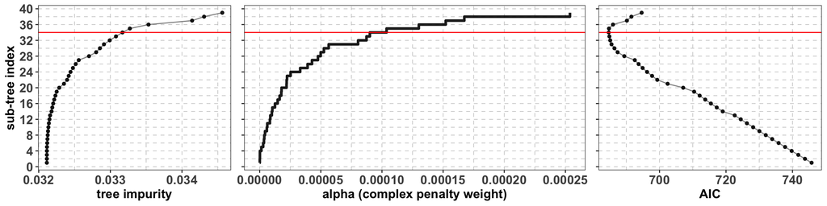

Note the expected monotonicity of tree impurity and alpha as functions of the sub-tree index. Note also that, as expected, as the sub-tree index increases, the AIC first descreases and then increases. The horizontal red line indicates the sub-tree index at which the AIC is minimized; the corresponding sub-tree is the optimally pruned tree. The estimates of the optimally pruned tree are reported in the output data frame of **nppR::get_npdata_with_propensity( )** under the columns whose names have the suffix “.pruned”.